# Botanical Heatmap Workflow

Natural England

## Project Background

Under the Natural Capital and Ecosystem Assessment (NCEA), Natural England have been working in partnership with the Botanical Society of Britain and Ireland (BSBI) to further develop their botanical heatmaps derived from plant occurrence records supplied from BSBI’s central plant distribution database (BSBI, 2022). The project aims to create easily interpretable spatial layers that will be available for operational use in advising tree planting schemes.

This repeatable workflow will output three heatmap data products, compiled within geopackages. These will have the following attributes:

*Ancient Woodland Indicator (AWI) Botanical Heatmap 2021*

Ancient Woodland Indicators heatmap geodatabase containing summarised counts of the number of ancient woodland indicators recorded per monad (1 x 1 km grid cells). Geopackage contains the count, species list, and when each species was last recorded within each monad. This will take into account survey effort by assigning the value -9999 where monads have been assessed to have poor survey effort below a minimal recording day threshold, and are highlighted as requiring further survey.

AWI Polygon vector layer:

- monad - unique 1km OS grid reference
- RDays_40 - Recorder days where over 40 taxa have been recorded on a single list on a single day by an individual recorder.
- region - Regional division the monad sits within
- totAWI - Total number of ancient woodland indicators recorded within the monad between 1970 and 2021

AWI_England_species_1km table fieldsAWI species table

- monad - unique 1km OS grid reference
- species - latin name for the species recorded
- commonName - common name for the species recorded
- lastRecorded - Year of the last record for the species within the monad

*Botanical heatmaps 1km 2021*

Summarised counts of the number of priority species (rare/scarce/threatened), positive habitat indicators and habitat indicators split out by broad habitat type, recorded per monad (1 x 1 km grid cells). Geopackage contains the count, species list and when the species were last recorded in each monad.

Botanical Heatmap polygon layer:

- monad - unique 1km OS grid reference
- RDays_40 - Recorder days where over 40 taxa have been recorded on a single list on a single day by an individual recorder.
- region - Regional division the monad sits within
- totPriority - total number of priority species recorded in the monad
- GB_Rare - Number of priority species with a GB rare status
- GB_Scarce - Number of priority species with a GB scarce status
- allHabs - Total number of positive habitat indicators, combined across all habitat types
- arable - number of positive habitat indicators associated with arable habitats
- boundary - number of positive habitat indicators associated with boundary habitats
- coastal - number of positive habitat indicators associated with coastal habitats
- fenMarshSwamp - number of positive habitat indicators associated with fen, marsh and swamp habitats
- freshwater - number of positive habitat indicators associated with freshwater habitats
- grassland - number of positive habitat indicators associated with grassland habitats
- heathBog - number of positive habitat indicators associated with heath and bog habitats
- inlandRock - number of positive habitat indicators associated with inland rock habitats
- montane - number of positive habitat indicators associated with montane habitats
- woodland - number of positive habitat indicators associated with woodland habitats

Priority species table:

- monad - unique 1km OS grid reference
- species - latin name for the species recorded
- commonName - common name for the species recorded
- lastRecorded - Year of the last record for the species within the monad

Habitat indicators species table:

- monad - unique 1km OS grid reference
- species - latin name for the species recorded
- commonName - common name for the species recorded
- lastRecorded - Year of the last record for the species within the monad

Broad Habitat associated species table:

- species - latin name for the species recorded
- commonName - common name for the species recorded
- arable - 1 if associated with broad habitat type in Plantatt, 0 if not associated
- boundary - 1 if associated with broad habitat type in Plantatt, 0 if not associated
- coastal - 1 if associated with broad habitat type in Plantatt, 0 if not associated
- fenMarshSwamp - 1 if associated with broad habitat type in Plantatt, 0 if not associated
- freshwater - 1 if associated with broad habitat type in Plantatt, 0 if not associated
- grassland - 1 if associated with broad habitat type in Plantatt, 0 if not associated
- heathBog - 1 if associated with broad habitat type in Plantatt, 0 if not associated
- inlandRock - 1 if associated with broad habitat type in Plantatt, 0 if not associated
- montane - 1 if associated with broad habitat type in Plantatt, 0 if not associated
- woodland - 1 if associated with broad habitat type in Plantatt, 0 if not associated

*Priority species heatmap 100m 2021*

summarised count of the number of priority species (GB rare, scarce or threatened) per hectare (100 x 100 m grid cells). Geopackage contains the count, species list and when the species w3ere last recorded in each monad

Priority species heatmap polygon layer:

- hectare - unique 100m grid square reference
- region - Regional division the monad sits within
- ttPrrty - total number of priority species recorded in the hectare
- GB_Rare - Number of priority species with have a GB rare status
- GB_Scarce - Number of priority species with have a GB scarce status

Priority species table:

- hectare - unique 100m grid square reference
- species - latin name for the species recorded
- commonName - common name for the species recorded
- lastRecorded - Year of the last record for the species within the monad

## Data Sources

The data source for the botanical heat maps were vascular plant species occurrence records held in the BSBI’s central plant distribution database (BSBI, 2022).

As well as data from the BSBI, supporting data were obtained from other sources for the spatial analysis. The Ordnance Survey (2021) British National Grids were used as a spatial framework for the grid cell divisions of 100 x 100 m (hectares), 1 x 1 km (monads) and 100 x 100 km (myriads). For regional and country boundaries, spatial data were obtained from the Office for National Statistics (2020) Open Geography Portal. These data were all available under an Open Government Licence.

```r
#BSBI shapefiles and csv files
#OS grid and admin areas
OS_1km <- sf::st_read('DataLayers/OS BNG grids/OS_BNG_grids_1km_grid.shp')
OS_10km <- sf::st_read('DataLayers/OS BNG grids/OS_BNG_grids_10km_grid.shp')
countries <- sf::st_read('DataLayers/Countries_(December_2020)_UK_BFC/Countries_(December_2020)_UK_BFC.shp')
regions <- sf::st_read('DataLayers/Regions_(December_2020)_EN_BFC/Regions_(December_2020)_EN_BFC.shp') %>% select(RGN20NM)
```

## Method

### 1. Clip OS grid to England and add in regional data

```r
# Create England template with OS 1km grid
## subset countries to England
England <- countries %>% dplyr::filter(CTRY20NM == 'England') %>% st_make_valid()
## crop OS 1km grid
Eng_OS_1km <- OS_1km %>% st_crop(England) %>% st_intersection(England)
## save out template
st_write(Eng_OS_1km, 'DataLayers/OS BNG grids/Eng_OS_1km.shp')

# Add in the regions
## load template
Eng_OS_1km  <- sf::st_read('DataLayers/OS BNG grids/Eng_OS_1km.shp') %>%
  select(monad=tile_name)
## find region the monad sits in
monad_region <- Eng_OS_1km  %>% st_centroid() %>% st_intersection(regions) %>%
  st_drop_geometry()
Eng_OS_region <-Eng_OS_1km %>% left_join(monad_region, by='monad')
st_write(Eng_OS_region, 'DataLayers/OS BNG grids/Eng_OS_region.shp')
## where no region found e.g. coast, find the nearest region
Eng_monad_region <- Eng_OS_region %>% filter(!is.na(Eng_OS_region$RGN20NM))
Eng_no_region <- Eng_OS_region %>% filter(is.na(Eng_OS_region$RGN20NM))
## find nearest region
regions <- regions %>% mutate(id = row_number()) %>% st_drop_geometry()
newRegion <- Eng_no_region %>% st_nearest_feature(regions) %>% tibble() %>%
  left_join(regions,by=c('.'='id'))
modNoRegion <- Eng_no_region  %>% cbind(newRegion) %>% select(monad,RGN20NM=RGN20NM.1)
## join the updated data back in
all_Eng_monad_region <- rbind(Eng_monad_region,modNoRegion)
## write out england monad template with regions
st_write(all_Eng_monad_region, 'DataLayers/DerivedLayers/Eng_OS_monad_region.shp')
```

### 2. Set file paths (ensure to update when conducting update of the layers)

```r
## filepath for recording days per monad ##
rDaysFilePath <- 'DataLayers/heatmap_reports_GB_20211129/heatmap_recording_effort_report_2021_11_29.shapefiles/results/recordingdays1000_VC1-VC112.shp'


## AWI filepaths ##
AWICountPath <- 'D:/NE/Work/BSBI_HeatMaps/DataLayers/heatmap_reports_GB_2021_11/Indicators by Broad Habitat/Ancient_wood_indicator_species_count1000_VC1-VC112.csv'
AWISpeciesPath <-'D:/NE/Work/BSBI_HeatMaps/DataLayers/heatmap_reports_GB_2021_11/Indicators by Broad Habitat/Ancient_wood_indicator_species_species1000_VC1-VC112.csv'


## 1km monad filepaths ##
prioritySpeciesPath <- 'D:/NE/Work/BSBI_HeatMaps/DataLayers/heatmap_reports_GB_2021_11/Priority Indicators/conservationStatus_species1000_VC1-VC112.csv'
combineCountPath <- 'D:/NE/Work/BSBI_HeatMaps/DataLayers/heatmap_combined_indicators_monad_report_to2021-11-29_2022_03_15.shapefiles/results/combined-indicator-counts_VC1-VC112.shp'
combinespeciesPath <- 'D:/NE/Work/BSBI_HeatMaps/DataLayers/heatmap_combined_indicators_monad_report_to2021-11-29_2022_03_15.shapefiles/results/combined-indicators_VC1-VC112.shp'

## 100m priority species filepaths ##
priorityPath <- 'D:/NE/Work/BSBI_HeatMaps/DataLayers/heatmap_reports_GB_20211129/heatmap_conservation_status_100m_report_2021_11_26.shapefiles/results/conservationStatus_species100_VC1-VC112.shp'

# Folder path to save outputs
outputFolder <- 'D:/NE/Work/BSBI_HeatMaps/Products'

#survey coverage threshold - update if changed after the below analysis
surveyCov <- 3
```

### 3. Compile survey effort for monads and determine a baseline for good survey coverage

- analysis of a baseline level of a monad having good survey coverage was carried out with the script ‘survey_effort_analysis.Rmd’. This compared the number of recording days against the total number of taxa recorded at a site (all taxa not just indicator species). Through comparisons with linear regression modelling, this demonstrated that on average after 3 recording days, over 200 taxa were recorded within a monad, which was observed across the difference regions. Discussions with experts at BSBI confirmed that this would provide an indication of a site having been well recorded and therefore 3 recording days were selected as a baseline measure for good coverage.

```r
# join recording days per monad
## load in monad template
all_Eng_monad_region <- st_read( 'DataLayers/DerivedLayers/Eng_OS_monad_region.shp') %>%
  rename(region=RGN20NM)

## load recording days per monad
surveyMonad <- st_read(rDaysFilePath) %>% st_drop_geometry() %>%
   filter(!region_nam %in% c("Scottish highlands and islands","Scottish lowlands","Scottish highlands and islands,Scottish lowlands","Wales" )) %>% select(-region_nam)
names(surveyMonad) <- c('monad','RDays_40')
## join days to template
Eng_surveyEffort <- all_Eng_monad_region  %>% left_join(surveyMonad, by='monad')  %>%
  mutate(RDays_40=replace_na(RDays_40,0))

# Analyse survey coverage
summary(Eng_surveyEffort$RDays_40)

# see survey_effort_analysis.Rmd for full analysis

#baseline of recording days showing good coverage
surveyCov = 3

#write out layer with survey coverage data
st_write(Eng_surveyEffort,'DataLayers/DerivedLayers/Eng_OS_monad_surveyEffort.shp')
```

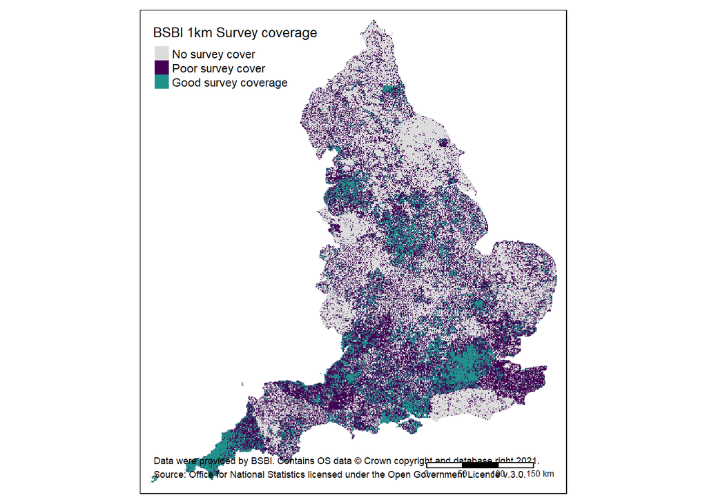

```r
#read in the survey data
surveyShape = sf::st_read('D:/NE/Work/BSBI_HeatMaps/DataLayers/DerivedLayers/Eng_OS_monad_surveyEffort.shp')
#categorise into good or poor coverage
hab_monad <- surveyShape %>% mutate(valueCat = ifelse(RDays_40 ==0, 'No survey cover',
                                         ifelse(RDays_40<=2, 'Poor survey cover',
                                                'Good survey coverage'))) %>%
  mutate(valueCat =  factor(valueCat,levels=c("No survey cover","Poor survey cover","Good survey coverage")))

#summary count of monads in each category
  results <- hab_monad %>% st_drop_geometry() %>%
    group_by(valueCat) %>%  summarise(count = n())

  total <- sum(results$count)
  results <- results %>%
    mutate(prop = round((count/total)*100,2))

#plot on a map
pal <- c('#DCDCDC', '#440154','#21918c')
map1 <- tm_shape(hab_monad) +
  tm_fill(col='valueCat', style='cat',palette = pal, reverse=T,title = 'BSBI 1km Survey coverage') +
  tm_scale_bar(position=c("right", "bottom")) +
  tm_credits(str_wrap('Data were provided by BSBI. Contains OS data © Crown copyright and database right 2021. Source: Office for National Statistics licensed under the Open Government Licence v.3.0.', width=90), position= 'left', size=0.6)
#tmap_save(map1, 'surveyCoverMap.png')
 map1
```

```r
#function for retrieving county summary data
  surveyCovSumm <- function(county,
                          countiesShape = 'D:/NE/Work/BSBI_HeatMaps/DataLayers/Counties_and_Unitary_Authorities_(December_2020)_UK_BUC/Counties_and_Unitary_Authorities_(December_2020)_UK_BUC.shp',
                          surveyShape = 'D:/NE/Work/BSBI_HeatMaps/DataLayers/DerivedLayers/Eng_OS_monad_surveyEffort.shp'){
  #load and filter to county
  counties <- st_read(countiesShape,quiet=T)
  selectCount <- counties %>% filter(CTYUA20NM ==county)
  if(nrow(selectCount)<1){stop('county name not found.')}
  #load in survey effort layer
  surveyCov <- st_read(surveyShape,quiet=T)
  ## find county monads
  monad_county <- surveyCov %>% suppressMessages(st_centroid()) %>%
    st_intersection(selectCount) %>%
    st_drop_geometry() %>% select(monad, RDays_40)
  cat('\n')
  summary(monad_county$RDays_40)
}

#comparison of Cornwall and Devon
surveyCovSumm(county='Cornwall')
```

```
##    Min. 1st Qu.  Median    Mean 3rd Qu.    Max.
##   0.000   2.000   3.000   3.616   5.000  36.000
```

```r
surveyCovSumm(county='Devon')
```

```
##    Min. 1st Qu.  Median    Mean 3rd Qu.    Max.
##   0.000   0.000   1.000   1.048   2.000  35.000
```

### 4. Create Ancient Woodland Inventory layers for geodatabase

*BotanicalHeatMaps_AWI_1970_2021*

- This layer is aimed specifically at supporting updates to the Ancient Woodland Inventory, plotting just the plant indicators for ancient woodland and allowing users to view the total number of indicators per monad, the species present and the date they were last recorded.
- An assumption is made that where there are no AWI records for a monad but good survey coverage (above baseline recorder days), then there are no AWIs present. However, where the number of AWIs for a monad is 0, but a monad has not had good survey coverage (below baseline recorder days) then the record has been updated to NA, representing a need for further survey.
- for writing out for use with Arc software, the NA (no data) records have been given the value -9999.

```r
# join count data to monad template
## load AWI count data
AWI_count <- readr::read_csv(AWICountPath,show_col_types = FALSE) %>% select(monad,totAWI=`total freq`)
## join to monad template
Eng_surveyEffort <-st_read('D:/NE/Work/BSBI_HeatMaps/DataLayers/DerivedLayers/Eng_OS_monad_surveyEffort.shp')
AWI_poly <- Eng_surveyEffort %>% select(monad,RDays_40,region) %>%
  left_join(AWI_count, by='monad')

surveyCov=3

# fill in NAs with 0 where survey effort is good coverage - above threshold days
## number of NA moads
nrow(AWI_poly[is.na(AWI_poly$totAWI),])
```

```
## [1] 27
```

```r
## update to 0 where survey day threshold exceeded
AWI_poly <- AWI_poly %>%
  mutate(totAWI= ifelse(is.na(totAWI) & RDays_40>=surveyCov, 0,totAWI))

# where survey coverage is < recording day threshold and totalAWI =0, replace with NA to indicate further survey needed
## remaining nas
nrow(AWI_poly[is.na(AWI_poly$totAWI),])
```

```
## [1] 27
```

```r
AWI_poly %>% filter(RDays_40 < surveyCov & totAWI ==0)
```

```
## Simple feature collection with 26756 features and 4 fields
## Geometry type: POLYGON
## Dimension:     XY
## Bounding box:  xmin: 82000 ymin: 5000 xmax: 656000 ymax: 657000
## Projected CRS: OSGB 1936 / British National Grid
## First 10 features:
##     monad RDays_40     region totAWI                       geometry
## 1  NT6500        0 North East      0 POLYGON ((365000 6e+05, 365...
## 2  NT6501        0 North East      0 POLYGON ((365000 601000, 36...
## 3  NT6502        0 North East      0 POLYGON ((365000 602000, 36...
## 4  NT6601        0 North East      0 POLYGON ((366000 601000, 36...
## 5  NT6801        0 North East      0 POLYGON ((368000 601000, 36...
## 6  NT6900        0 North East      0 POLYGON ((369000 6e+05, 369...
## 7  NT6901        0 North East      0 POLYGON ((369000 601000, 36...
## 8  NT6902        0 North East      0 POLYGON ((369000 602000, 36...
## 9  NT6903        0 North East      0 POLYGON ((369000 603000, 36...
## 10 NT7002        0 North East      0 POLYGON ((370000 602000, 37...
```

```r
## update to NA where poor coverage
AWI_poly <- AWI_poly %>%
  mutate(totAWI= ifelse(RDays_40 < surveyCov & totAWI ==0, NA,totAWI))

# convert NAs to -9999 value so can be read in all GI softwares
AWI_poly$totAWI[is.na(AWI_poly$totAWI)] <- -9999

# write out to geopackage
#st_write(AWI_poly,'Products/AWI_England_1km.gpkg','AWI_poly',driver='GPKG')

# create species table
## read in species data per monad
AWI_species <- readr::read_csv(AWISpeciesPath,show_col_types = FALSE) %>%
  filter(`latest date`!=0) %>% select(-qualifier) %>%
  select(monad,species=group,commonName=vernacular,lastRecorded=`latest date`) %>%
  mutate(commonName = ifelse(commonName=="",NA,commonName))

#write to geopackage
#st_write(AWI_species,paste0(outputFolder,'/AWI_England_1km.gpkg'),'AWI_species',driver='GPKG',append=TRUE)

#view geopackage
sf::st_layers(paste0(outputFolder,'/AWI_England_1km.gpkg'))
```

```
## Driver: GPKG
## Available layers:
##    layer_name geometry_type features fields
## 1    AWI_poly       Polygon   133416      4
## 2 AWI_species            NA  3362964      4
```

```r
# total monads
Engtotal <- nrow(AWI_poly)
# 27 monads requiring further survey
namonad <- nrow(AWI_poly[is.na(AWI_poly$totAWI),])
# number of monads with 0 indicators present
absentMonads <- AWI_poly %>% filter(totAWI==0) %>% nrow()
#number of monads with 1 or more indicator present
presentMonads <- AWI_poly %>% filter(totAWI>0) %>% nrow()
#number of monads with 1 or more indicator present
tenMonads <- AWI_poly %>% filter(totAWI>=10) %>% nrow()
#summary of data
summary(AWI_poly$totAWI)
```

```
##    Min. 1st Qu.  Median    Mean 3rd Qu.    Max.
##   -9999       1      11   -1989      29     138
```

```r
#ggplot(AWI_poly, aes(x=totAWI)) +
 # geom_histogram()  + xlab("Number of Ancient Woodland Indicators per monad")
```

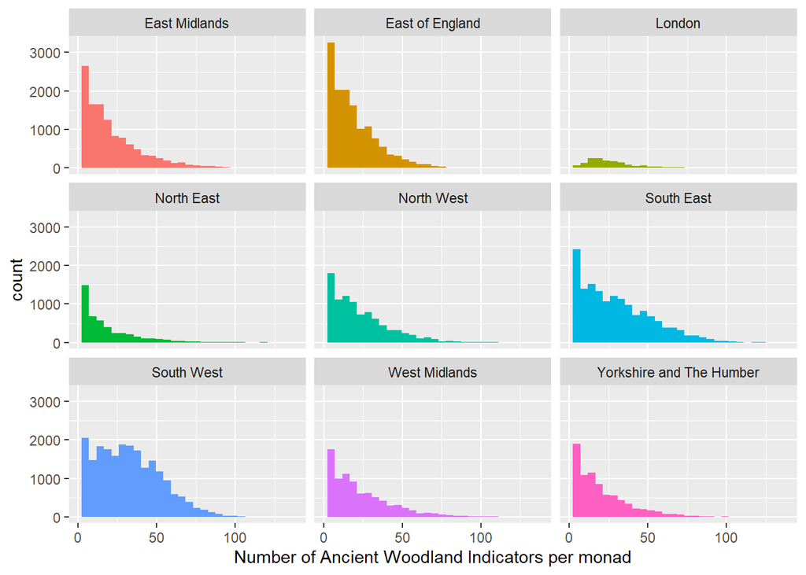

```r
# plot with range limits
AWIplot <- ggplot(AWI_poly, aes(x=totAWI, fill=region)) +
  geom_histogram(show.legend = F)  + xlab("Number of Ancient Woodland Indicators per monad") +
  xlim(1,138)
AWIplot + facet_wrap(~region)
```

### 5. Create Priority species 1km layers for geodatabase

*BotanicalHeatMaps_Indicators_1970_20211*

- These layers are created for tree screening at the monad 1km scale. They include data per monad of the number of priority species (GB rare, scare or threatened species) and the number of positive habitat indicator species, with these also broken down by broad habitat.
- As above, it has been assumed that where there are no records for a monad but good survey coverage (above baseline recorder days), then no indicators are present, and where there isnt good coverage and a monad is recorded as 0, this has been updated to NA, representing a need for further survey.
- for writing out for use with Arc software, the NA (no data) records have been given the value -9999.

```r
#Priority species
priority <- readr::read_csv(prioritySpeciesPath,show_col_types = FALSE)
#load monad survey data
Eng_surveyEffort <-st_read('D:/NE/Work/BSBI_HeatMaps/DataLayers/DerivedLayers/Eng_OS_monad_surveyEffort.shp')
#filter to those in monad template and standardise names
priority_clean <- priority  %>% select(monad, species=group, commonName=vernacular, GBstatus=`National status`, lastRecorded=`latest date`) %>%
  filter(monad %in% Eng_surveyEffort$monad) %>%
  mutate(commonName = ifelse(commonName=="",NA,commonName))
```

### 6. Create main table for indicators geodatabase

```r
# priority columns for the main table
priorityTable <- priority_clean %>%
  mutate(National_Rare=ifelse(GBstatus=="NR"|GBstatus=="NR,NS",1,0)) %>%
  mutate(National_Scarce=ifelse(GBstatus=="NS"|GBstatus=="NR,NS",1,0)) %>%
  group_by(monad) %>%
  summarise(totPriority=n(), GB_Rare=sum(National_Rare),GB_Scarce=sum(National_Scarce))

# join to monad grid to create main table
mainTable <- Eng_surveyEffort %>% select(monad,RDays_40,region) %>%
  left_join(priorityTable, by='monad') %>%
  mutate(totPriority= ifelse(is.na(totPriority) & RDays_40>=surveyCov, 0,totPriority),
         GB_Rare = ifelse(is.na(GB_Rare) & RDays_40>=surveyCov, 0, GB_Rare),
         GB_Scarce = ifelse(is.na(GB_Scarce) & RDays_40>=surveyCov, 0, GB_Scarce)) %>% #fill in NAs with 0 where survey effort is good coverage
  mutate(totPriority= ifelse(RDays_40<surveyCov & totPriority == 0,NA,totPriority),
         GB_Rare = ifelse(RDays_40<surveyCov & GB_Rare == 0, NA, GB_Rare),
         GB_Scarce = ifelse(RDays_40<surveyCov & GB_Scarce == 0, NA, GB_Scarce))

#read in data
combined_count <- st_read(combineCountPath) %>% st_drop_geometry()
```

```r
## check names at this point in case these have changed!

# clean names
combined <- combined_count %>%
  filter(monad %in% Eng_surveyEffort$monad) %>%
  select(monad, allHabs=total_freq,
         arable = Arable_ind,
         boundary=Boundary_a,
         coastal = Coastal_in,
         fenMarshSwamp = Fen_marsh_,
         freshwater=Freshwater,
         grassland=Grassland_,
         heathBog = Heath_and_,
         inlandRock = Inland_roc,
         montane = Montane_in,
         woodland=Woodland_i )

# join to rest of the data
mainTable <- mainTable %>% left_join(combined, by='monad') %>%
  mutate(allHabs = ifelse(allHabs == 0 & RDays_40 < surveyCov, NA, allHabs)) %>%
  mutate(arable = ifelse(arable == 0 & RDays_40 < surveyCov, NA, arable))  %>%
mutate(boundary = ifelse(boundary == 0 & RDays_40 < surveyCov, NA, boundary))  %>%
  mutate(coastal = ifelse(coastal == 0 & RDays_40 < surveyCov, NA, coastal))  %>%
  mutate(fenMarshSwamp = ifelse(fenMarshSwamp == 0 & RDays_40 < surveyCov, NA, fenMarshSwamp))  %>%
  mutate(freshwater = ifelse(freshwater == 0 & RDays_40 < surveyCov, NA, freshwater))  %>%
  mutate(grassland = ifelse(grassland == 0 & RDays_40 < surveyCov, NA, grassland))  %>%
  mutate(heathBog = ifelse(heathBog == 0 & RDays_40 < surveyCov, NA,heathBog))  %>%
  mutate(inlandRock = ifelse(inlandRock == 0 & RDays_40 < surveyCov, NA,inlandRock))  %>%
  mutate(montane = ifelse(montane == 0 & RDays_40 < surveyCov, NA, montane))  %>%
  mutate(woodland = ifelse(woodland == 0 & RDays_40 < surveyCov, NA, woodland))

# convert NAs to -9999 value so can be read in all GI softwares
 mainTable <- mainTable %>%
   mutate(across(totPriority:woodland, ~ replace_na(.x,-9999)))

# write out layers to geopackage
#st_write(mainTable,paste0(outputFolder,'/BotanicalHeatMaps_Indicators_1970_2021.gpkg'),'BotanicalIndicators_England_1km',driver='GPKG')
#st_write(priority_clean,paste0(outputFolder,'/BotanicalHeatMaps_Indicators_1970_2021.gpkg'),'Priority_England_species_1km',driver='GPKG',append=TRUE)

#view geopackage
st_layers(paste0(outputFolder,'/BotanicalHeatMaps_Indicators_1970_2021.gpkg'))
```

```
## Driver: GPKG
## Available layers:
##                                layer_name geometry_type features fields
## 1         BotanicalIndicators_England_1km       Polygon   133416     17
## 2            Priority_England_species_1km            NA    46462      5
## 3 BotanicalIndicators_England_species_1km            NA  6004325      4
## 4         broadHabitat_associated_species            NA     1232     12
```

### 7. Create habitat indicator layers for geodatabase

```r
# read in combined 1km species table
combined_species <-st_read(combinespeciesPath) %>% st_drop_geometry()
```

```r
#reformat
habSpecies <- combined_species %>% filter(monad_2_ %in% Eng_surveyEffort$monad) %>%
  select(monad = monad_2_,
         species=group,
         commonName=vernacular,
         arable = Arable_ind,
         boundary=Boundary_a,
         coastal = Coastal_in,
         fenMarshSwamp = Fen_marsh_,
         freshwater=Freshwater,
         grassland=Grassland_,
         heathBog = Heath_and_,
         inlandRock = Inland_roc,
         montane = Montane_in,
         woodland=Woodland_i,
         lastRecorded = latest_dat )

#species lists per monad
species_monad <- habSpecies %>% select(monad, species, commonName, lastRecorded)
#st_write(species_monad,paste0(outputFolder,'/BotanicalHeatMaps_Indicators_1970_2021.gpkg'),'BotanicalIndicators_England_species_1km',driver='GPKG',append=TRUE)

#species to broad habitats table
habSpecies <- habSpecies %>% select(species, commonName,arable:woodland)%>% unique()
species_match <- habSpecies %>%
   mutate(across(arable:woodland, ~ if_else(.x=='match',1,0))) %>%
   mutate(across(arable:woodland, ~ replace_na(.x,0)))
#st_write(species_match,paste0(outputFolder,'/BotanicalHeatMaps_Indicators_1970_2021.gpkg'),'broadHabitat_associated_species',driver='GPKG',append=TRUE)


#view geopackage
st_layers(paste0(outputFolder,'/BotanicalHeatMaps_Indicators_1970_2021.gpkg'))
```

```
## Driver: GPKG
## Available layers:
##                                layer_name geometry_type features fields
## 1         BotanicalIndicators_England_1km       Polygon   133416     17
## 2            Priority_England_species_1km            NA    46462      5
## 3 BotanicalIndicators_England_species_1km            NA  6004325      4
## 4         broadHabitat_associated_species            NA     1232     12
```

*BotanicalHeatMaps_PrioritySp100m_1970_20211*

```r
# read in data
priority_100 <-  st_read(priorityPath)

# unique spatial grid for England
hecGrid <- priority_100 %>% select(hectare) %>% unique() %>%
  st_crop(England) %>% st_intersection(England)

# add in regions
hectare_region <- hecGrid %>% st_centroid() %>% st_intersection(regions) %>% st_drop_geometry()
hecGrid_region <-hecGrid %>% left_join(hectare_region[,c('hectare','RGN20NM')], by='hectare') %>% rename(region =RGN20NM)

#write species table out
species_table <- priority_100 %>% st_drop_geometry() %>% select(hectare, species=group, commonName=vernacular, GBstatus=National_s, lastRecorded=latest_dat) %>% filter(hectare %in% hecGrid_region$hectare)

#summmarise species count per hectare
priorityTable <- species_table %>%
  mutate(National_Rare=ifelse(GBstatus=="NR"|GBstatus=="NR,NS",1,0)) %>%
  mutate(National_Scarce=ifelse(GBstatus=="NS"|GBstatus=="NR,NS",1,0)) %>%
  group_by(hectare) %>%
  summarise(totPriority=n(), GB_Rare=sum(National_Rare),GB_Scarce=sum(National_Scarce))

# join to hectare grid  to create main table
mainTable <- hecGrid_region %>%
  left_join(priorityTable, by='hectare')

#write as geopackage
#st_write(mainTable,paste0(outputFolder,'/BotanicalHeatMaps_PrioritySp100m_1970_2021.gpkg'),'PriorityIndicators_England_100m',driver='GPKG')
#st_write(species_table,paste0(outputFolder,'/BotanicalHeatMaps_PrioritySp100m_1970_2021.gpkg'),'PriorityIndicators_species_England_100m',driver='GPKG',append=TRUE)


#view geopackage
st_layers(paste0(outputFolder,'/BotanicalHeatMaps_PrioritySp100m_1970_2021.gpkg'))
```

[output not shown]

## Assumptions and Considerations for use

There are several assumptions made throughout the analysis which are key to consider when using these data:

- These maps provide an indication of areas where botanically valuable habitats are present to help guide tree planting decisions. However, there are a number of caveats that need to be taken into account when using them. Although detailed, they are not comprehensive, relying on data collected by volunteers often at a coarse capture resolution. Our analysis also makes assumptions on what constitutes ‘good’ recording coverage for a monad. When using these maps for the purpose of tree screening, they should also be consulted alongside other environmental datasets to assess site suitability.
- This analysis uses recorder days as a proxy for survey coverage. This is a measure of the number of days where more than 40 species have been recorded during a single visit. However, there is regional bias in species diversity decreasing from south to north. Similarly, many coastal monads contain little land and therefore have fewer species present.
- Crucially, some sites chosen for tree planting may have priority species or habitat indicators present that are not shown on the maps, as they have not been visited or well recorded by BSBI recorders. For these sites, field surveys will be required. Therefore, these maps should be used with caution and local site experts should be consulted wherever possible.
- The status of priority species is currently flagged as those which are rare and/or threatened at the GB scale. Use of equivalent species at the England-level would identify a different pool of priority species. However, a review of the species list demonstrated that the majority of species are included within the positive indicator lists, although with slightly different threatened and rare statuses noted. Globally or highly restricted endemic species were not reviewed, although many are likely to fall within the national threatened, rare and scarce species lists.
- Similarly, some local priority species may not necessarily mean they are a national priority species, and so local environmental teams may be aware of other key species to consider when planning actions on the ground.
- The variation in survey coverage by BSBI recorders will also greatly impact the coverage of priority species and habitat indicators on these maps; wherever possible we have attempted to alleviate some of this bias through the localised benchmarking used to produce the botanical value map. Survey coverage also varies with the capture resolution of recording. Here we have only used records captured at the monad scale (1 x 1 km) however this does present a notable difference with areas which have historically captured data at lower resolution, with a defined difference notable between Cornwall and Devon.